# CustomerSegmentation-Copy1

## Asiakassegmentointiprojekti

Tämän projektin tarkoituksena on tarkastella ja luoda asiakassegmenttejä erään kuvitteellisen yrityksen asiakasdatasta. Data tähän projektiin on haettu Kagglesta. Pyrkimykseni on tuoda esiin mittareita, kuten

- (keski)kulutus erilaisissa asiakasryhmissä (iän, siviilisäädyn, tai perhetaustan mukaan jaoteltuna)
- käyttäytymismallit, millaisia asiointikanavia käytetään
- miten kampanjoihin reagoidaan eri ryhmissä

Yllä mainitut ovat olleet suuntaa antavia näkökulmia projektin toteuttamiseksi. Ennen kaikkea kuitenkin pyrin tuomaan tässä esiin osaamistani. Painopisteet tässä projektissa keskittyvät data-analyysivaiheeseen (segmentointi, visualisointi) datan siivoamisen jäädessä enemmän taka-alalle.

### Projektin valmistelu

Ladataan tarvittavat kirjastot ja tiedosto:

```python
import pandas as pd
```

```python
import matplotlib.pyplot as plt
```

```python
import numpy as np
```

```python
df = pd.read_csv(r"C:\Users\jsman\.vscode\Python\Jupyter_projects\marketing_campaign.csv", sep='\t')
```

```python
df
```

|  | ID | Year_Birth | Education | Marital_Status | Income | Kidhome | Teenhome | Dt_Customer | Recency | MntWines | ... | NumWebVisitsMonth | AcceptedCmp3 | AcceptedCmp4 | AcceptedCmp5 | AcceptedCmp1 | AcceptedCmp2 | Complain | Z_CostContact | Z_Revenue | Response |
| --- | --- | --- | --- | --- | --- | --- | --- | --- | --- | --- | --- | --- | --- | --- | --- | --- | --- | --- | --- | --- | --- |
| 0 | 5524 | 1957 | Graduation | Single | 58138.0 | 0 | 0 | 04-09-2012 | 58 | 635 | ... | 7 | 0 | 0 | 0 | 0 | 0 | 0 | 3 | 11 | 1 |
| 1 | 2174 | 1954 | Graduation | Single | 46344.0 | 1 | 1 | 08-03-2014 | 38 | 11 | ... | 5 | 0 | 0 | 0 | 0 | 0 | 0 | 3 | 11 | 0 |
| 2 | 4141 | 1965 | Graduation | Together | 71613.0 | 0 | 0 | 21-08-2013 | 26 | 426 | ... | 4 | 0 | 0 | 0 | 0 | 0 | 0 | 3 | 11 | 0 |
| 3 | 6182 | 1984 | Graduation | Together | 26646.0 | 1 | 0 | 10-02-2014 | 26 | 11 | ... | 6 | 0 | 0 | 0 | 0 | 0 | 0 | 3 | 11 | 0 |
| 4 | 5324 | 1981 | PhD | Married | 58293.0 | 1 | 0 | 19-01-2014 | 94 | 173 | ... | 5 | 0 | 0 | 0 | 0 | 0 | 0 | 3 | 11 | 0 |
| ... | ... | ... | ... | ... | ... | ... | ... | ... | ... | ... | ... | ... | ... | ... | ... | ... | ... | ... | ... | ... | ... |
| 2235 | 10870 | 1967 | Graduation | Married | 61223.0 | 0 | 1 | 13-06-2013 | 46 | 709 | ... | 5 | 0 | 0 | 0 | 0 | 0 | 0 | 3 | 11 | 0 |
| 2236 | 4001 | 1946 | PhD | Together | 64014.0 | 2 | 1 | 10-06-2014 | 56 | 406 | ... | 7 | 0 | 0 | 0 | 1 | 0 | 0 | 3 | 11 | 0 |
| 2237 | 7270 | 1981 | Graduation | Divorced | 56981.0 | 0 | 0 | 25-01-2014 | 91 | 908 | ... | 6 | 0 | 1 | 0 | 0 | 0 | 0 | 3 | 11 | 0 |
| 2238 | 8235 | 1956 | Master | Together | 69245.0 | 0 | 1 | 24-01-2014 | 8 | 428 | ... | 3 | 0 | 0 | 0 | 0 | 0 | 0 | 3 | 11 | 0 |
| 2239 | 9405 | 1954 | PhD | Married | 52869.0 | 1 | 1 | 15-10-2012 | 40 | 84 | ... | 7 | 0 | 0 | 0 | 0 | 0 | 0 | 3 | 11 | 1 |

2240 rows × 29 columns

```python
df.dtypes
```

```
ID                       int64
Year_Birth               int64
Education               object
Marital_Status          object
Income                 float64
Kidhome                  int64
Teenhome                 int64
Dt_Customer             object
Recency                  int64
MntWines                 int64
MntFruits                int64
MntMeatProducts          int64
MntFishProducts          int64
MntSweetProducts         int64
MntGoldProds             int64
NumDealsPurchases        int64
NumWebPurchases          int64
NumCatalogPurchases      int64
NumStorePurchases        int64
NumWebVisitsMonth        int64
AcceptedCmp3             int64
AcceptedCmp4             int64
AcceptedCmp5             int64
AcceptedCmp1             int64
AcceptedCmp2             int64
Complain                 int64
Z_CostContact            int64
Z_Revenue                int64
Response                 int64
dtype: object
```

Käsitellään raaka-data (turhat rivit/luokat, tyhjien arvojen käsittely ja korvaus ryhmäkeskiarvoilla, pvm:n muunnos

```python
df = df[~df['Marital_Status'].isin(['YOLO','Absurd'])].copy()
```

```python
df['Marital_Status'] = df['Marital_Status'].str.replace('Alone', 'Single')
```

```python
df['Income'].mean()
```

```
52232.51084990959
```

```python
df['Income'] = df.groupby('Marital_Status')['Income'].transform(lambda x:x.fillna(x.mean()))
```

```python
df['Income'].mean()
```

```
52230.83041519854
```

```python
df['Dt_Customer'] = pd.to_datetime(df['Dt_Customer'], dayfirst=True)
```

```python
df.isna().sum()
```

```
ID                     0
Year_Birth             0
Education              0
Marital_Status         0
Income                 0
Kidhome                0
Teenhome               0
Dt_Customer            0
Recency                0
MntWines               0
MntFruits              0
MntMeatProducts        0
MntFishProducts        0
MntSweetProducts       0
MntGoldProds           0
NumDealsPurchases      0
NumWebPurchases        0
NumCatalogPurchases    0
NumStorePurchases      0
NumWebVisitsMonth      0
AcceptedCmp3           0
AcceptedCmp4           0
AcceptedCmp5           0
AcceptedCmp1           0
AcceptedCmp2           0
Complain               0
Z_CostContact          0
Z_Revenue              0
Response               0
dtype: int64
```

### Datan Segmentointi: Ikäluokat

```python
df2 = df.copy()
```

```python
df2['Age'] = 2024 - df2['Year_Birth']
```

```python
df2
```

|  | ID | Year_Birth | Education | Marital_Status | Income | Kidhome | Teenhome | Dt_Customer | Recency | MntWines | ... | AcceptedCmp3 | AcceptedCmp4 | AcceptedCmp5 | AcceptedCmp1 | AcceptedCmp2 | Complain | Z_CostContact | Z_Revenue | Response | Age |
| --- | --- | --- | --- | --- | --- | --- | --- | --- | --- | --- | --- | --- | --- | --- | --- | --- | --- | --- | --- | --- | --- |
| 0 | 5524 | 1957 | Graduation | Single | 58138.0 | 0 | 0 | 2012-09-04 | 58 | 635 | ... | 0 | 0 | 0 | 0 | 0 | 0 | 3 | 11 | 1 | 67 |
| 1 | 2174 | 1954 | Graduation | Single | 46344.0 | 1 | 1 | 2014-03-08 | 38 | 11 | ... | 0 | 0 | 0 | 0 | 0 | 0 | 3 | 11 | 0 | 70 |
| 2 | 4141 | 1965 | Graduation | Together | 71613.0 | 0 | 0 | 2013-08-21 | 26 | 426 | ... | 0 | 0 | 0 | 0 | 0 | 0 | 3 | 11 | 0 | 59 |
| 3 | 6182 | 1984 | Graduation | Together | 26646.0 | 1 | 0 | 2014-02-10 | 26 | 11 | ... | 0 | 0 | 0 | 0 | 0 | 0 | 3 | 11 | 0 | 40 |
| 4 | 5324 | 1981 | PhD | Married | 58293.0 | 1 | 0 | 2014-01-19 | 94 | 173 | ... | 0 | 0 | 0 | 0 | 0 | 0 | 3 | 11 | 0 | 43 |
| ... | ... | ... | ... | ... | ... | ... | ... | ... | ... | ... | ... | ... | ... | ... | ... | ... | ... | ... | ... | ... | ... |
| 2235 | 10870 | 1967 | Graduation | Married | 61223.0 | 0 | 1 | 2013-06-13 | 46 | 709 | ... | 0 | 0 | 0 | 0 | 0 | 0 | 3 | 11 | 0 | 57 |
| 2236 | 4001 | 1946 | PhD | Together | 64014.0 | 2 | 1 | 2014-06-10 | 56 | 406 | ... | 0 | 0 | 0 | 1 | 0 | 0 | 3 | 11 | 0 | 78 |
| 2237 | 7270 | 1981 | Graduation | Divorced | 56981.0 | 0 | 0 | 2014-01-25 | 91 | 908 | ... | 0 | 1 | 0 | 0 | 0 | 0 | 3 | 11 | 0 | 43 |
| 2238 | 8235 | 1956 | Master | Together | 69245.0 | 0 | 1 | 2014-01-24 | 8 | 428 | ... | 0 | 0 | 0 | 0 | 0 | 0 | 3 | 11 | 0 | 68 |
| 2239 | 9405 | 1954 | PhD | Married | 52869.0 | 1 | 1 | 2012-10-15 | 40 | 84 | ... | 0 | 0 | 0 | 0 | 0 | 0 | 3 | 11 | 1 | 70 |

2236 rows × 30 columns

**Lisätään ikäsegmenttisarake ikä-sarakketta hyödyntäen:**

```python
choices = [
        df2['Age']< 18,
        (df2['Age']>= 18) & (df2['Age']< 25),
        (df2['Age']>= 25) & (df2['Age']< 43),
        (df2['Age']>= 43) & (df2['Age']< 60),
        df2['Age']>= 60
]
segments = ['teen','adolescent', 'young_adult','middle_aged','pensioner']

df2['age_segment'] = np.select(choices,segments, default='unknown')
```

```python
df2.groupby('age_segment').size()
```

```
age_segment
middle_aged    1106
pensioner       785
young_adult     345
dtype: int64
```

## Kokonaiskulutus ja keskikulutus ikäluokittain

Asiakkaiden kulutustottumuksia (paljonko kulutetaan) tarkastellaan keski-ikäisten, nuorien aikuisten ja eläkeläisten ryhmissä, josta aineisto koostuu.

Viiniä kuluu eläkeläisillä eniten, hedelmät maistuvat nuorille, kummatkin suosivat kalaa ja makeita tuotteita suht samoissa määrin.

```python
age_consumption = df2.groupby('age_segment')[['MntWines','MntFruits','MntMeatProducts','MntFishProducts','MntSweetProducts','MntGoldProds']].agg(['sum','mean']).round(2)
age_consumption
```

| age_segment | MntWines sum | MntWines mean | MntFruits sum | MntFruits mean | MntMeatProducts sum | MntMeatProducts mean | MntFishProducts sum | MntFishProducts mean | MntSweetProducts sum | MntSweetProducts mean | MntGoldProds sum | MntGoldProds mean |
| --- | --- | --- | --- | --- | --- | --- | --- | --- | --- | --- | --- | --- |
| middle_aged | 295859 | 267.50 | 26531 | 23.99 | 161941 | 146.42 | 37042 | 33.49 | 27565 | 24.92 | 44272 | 40.03 |
| pensioner | 295725 | 376.72 | 22206 | 28.29 | 144407 | 183.96 | 33143 | 42.22 | 22774 | 29.01 | 38768 | 49.39 |
| young_adult | 87877 | 254.72 | 10005 | 29.00 | 66895 | 193.90 | 13453 | 38.99 | 10215 | 29.61 | 15077 | 43.70 |

**Seuraavaksi asiointikanavat ja -muodot samojen ikäryhmien mukaan. Perus kivijalka on keskimäärin suosituin kaikissa ryhmissä, myös nettiostaminen on tämän jälkeen suosittua.**

```python
age_consumption_medium = df2.groupby('age_segment')[['NumDealsPurchases','NumWebPurchases','NumCatalogPurchases','NumStorePurchases']].agg(['sum','mean']).round(2)
age_consumption_medium
```

| age_segment | NumDealsPurchases sum | NumDealsPurchases mean | NumWebPurchases sum | NumWebPurchases mean | NumCatalogPurchases sum | NumCatalogPurchases mean | NumStorePurchases sum | NumStorePurchases mean |
| --- | --- | --- | --- | --- | --- | --- | --- | --- |
| middle_aged | 2742 | 2.48 | 4426 | 4.00 | 2552 | 2.31 | 6115 | 5.53 |
| pensioner | 1873 | 2.39 | 3537 | 4.51 | 2549 | 3.25 | 5015 | 6.39 |
| young_adult | 579 | 1.68 | 1166 | 3.38 | 845 | 2.45 | 1815 | 5.26 |

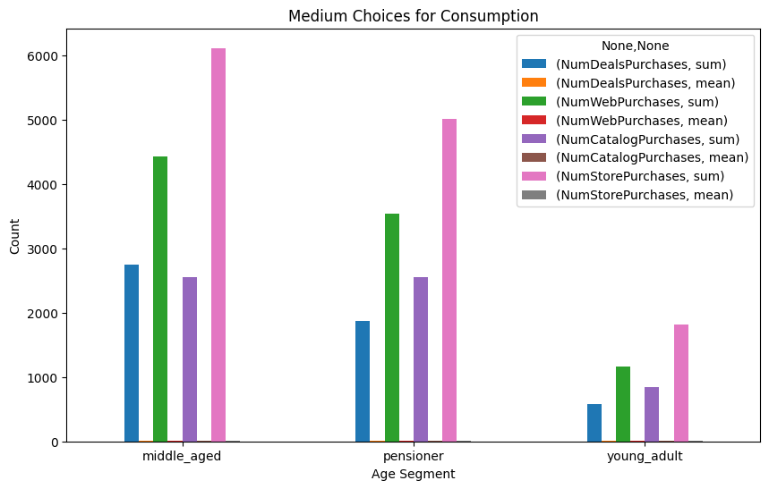

```python
age_consumption_medium.plot(kind='bar', figsize=(10,6))
plt.title('Medium Choices for Consumption')
plt.xlabel('Age Segment')
plt.ylabel('Count')
plt.xticks(rotation=0)
plt.show()
```

### Asiakassegmentit: lapsiperheet ja lapsettomat

Luodaan uusi sarake 'Totalchildren' ja luodaan ryhmittely:

```python
df2['Totalchildren'] = df2['Kidhome'] + df2['Teenhome']
```

```python
consumption_with_children = df2.groupby('Totalchildren')[['MntWines','MntFruits','MntMeatProducts','MntFishProducts','MntSweetProducts','MntGoldProds']].agg(['sum','mean']).round(2)
consumption_with_children
```

| Totalchildren | MntWines sum | MntWines mean | MntFruits sum | MntFruits mean | MntMeatProducts sum | MntMeatProducts mean | MntFishProducts sum | MntFishProducts mean | MntSweetProducts sum | MntSweetProducts mean | MntGoldProds sum | MntGoldProds mean |
| --- | --- | --- | --- | --- | --- | --- | --- | --- | --- | --- | --- | --- |
| 0 | 310190 | 487.72 | 33235 | 52.26 | 237100 | 372.80 | 48426 | 76.14 | 33792 | 53.13 | 40519 | 63.71 |
| 1 | 300578 | 266.94 | 21824 | 19.38 | 111153 | 98.71 | 30043 | 26.68 | 22887 | 20.33 | 45910 | 40.77 |
| 2 | 59610 | 141.59 | 3317 | 7.88 | 21597 | 51.30 | 4794 | 11.39 | 3524 | 8.37 | 10702 | 25.42 |
| 3 | 9083 | 171.38 | 366 | 6.91 | 3393 | 64.02 | 375 | 7.08 | 351 | 6.62 | 986 | 18.60 |

Tarkastellaan vielä kampanjaan osallistumisaktiivisuus. Kampanjat 1 ja 5 ovat lapsettomien suosiossa, 3 ja 4 yksi- ja kaksilapsisten. Muutoin luvuissa tukintavaraa keskiarvoista huolimatta, koska ryhmien koot ovat huomattavan erisuuruisia.

```python
cmp_with_children = df2.groupby('Totalchildren')[['AcceptedCmp1','AcceptedCmp2','AcceptedCmp3','AcceptedCmp4','AcceptedCmp5']].agg(['sum', 'mean','count'])
cmp_with_children
```

| Totalchildren | AcceptedCmp1 sum | AcceptedCmp1 mean | AcceptedCmp1 count | AcceptedCmp2 sum | AcceptedCmp2 mean | AcceptedCmp2 count | AcceptedCmp3 sum | AcceptedCmp3 mean | AcceptedCmp3 count | AcceptedCmp4 sum | AcceptedCmp4 mean | AcceptedCmp4 count | AcceptedCmp5 sum | AcceptedCmp5 mean | AcceptedCmp5 count |
| --- | --- | --- | --- | --- | --- | --- | --- | --- | --- | --- | --- | --- | --- | --- | --- |
| 0 | 109 | 0.171384 | 636 | 18 | 0.028302 | 636 | 48 | 0.075472 | 636 | 69 | 0.108491 | 636 | 137 | 0.215409 | 636 |
| 1 | 27 | 0.023979 | 1126 | 9 | 0.007993 | 1126 | 85 | 0.075488 | 1126 | 79 | 0.070160 | 1126 | 21 | 0.018650 | 1126 |
| 2 | 4 | 0.009501 | 421 | 3 | 0.007126 | 421 | 29 | 0.068884 | 421 | 16 | 0.038005 | 421 | 3 | 0.007126 | 421 |
| 3 | 3 | 0.056604 | 53 | 0 | 0.000000 | 53 | 1 | 0.018868 | 53 | 3 | 0.056604 | 53 | 1 | 0.018868 | 53 |

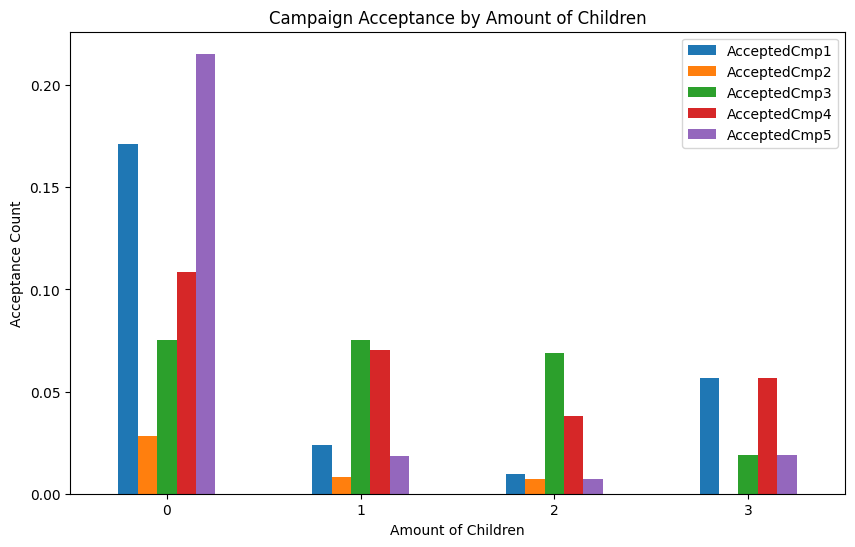

```python
cmp_with_children2 = df2.groupby('Totalchildren')[['AcceptedCmp1','AcceptedCmp2','AcceptedCmp3','AcceptedCmp4','AcceptedCmp5']].mean()
cmp_with_children2.plot(kind='bar', figsize=(10,6))
plt.title('Campaign Acceptance by Amount of Children')
plt.xlabel('Amount of Children')
plt.ylabel('Acceptance Count')
plt.xticks(rotation=0)
plt.show()
```

## Asiakassegmentti: asiakkuuden kesto

**Luodaan uusi sarake, 'Customer_For':**

```python
df2['Customer_For'] = (pd.Timestamp.now() - df2['Dt_Customer']).dt.days
```

```python
df2
```

|  | ID | Year_Birth | Education | Marital_Status | Income | Kidhome | Teenhome | Dt_Customer | Recency | MntWines | ... | AcceptedCmp1 | AcceptedCmp2 | Complain | Z_CostContact | Z_Revenue | Response | Age | age_segment | Totalchildren | Customer_For |
| --- | --- | --- | --- | --- | --- | --- | --- | --- | --- | --- | --- | --- | --- | --- | --- | --- | --- | --- | --- | --- | --- |
| 0 | 5524 | 1957 | Graduation | Single | 58138.0 | 0 | 0 | 2012-09-04 | 58 | 635 | ... | 0 | 0 | 0 | 3 | 11 | 1 | 67 | pensioner | 0 | 4475 |
| 1 | 2174 | 1954 | Graduation | Single | 46344.0 | 1 | 1 | 2014-03-08 | 38 | 11 | ... | 0 | 0 | 0 | 3 | 11 | 0 | 70 | pensioner | 2 | 3925 |
| 2 | 4141 | 1965 | Graduation | Together | 71613.0 | 0 | 0 | 2013-08-21 | 26 | 426 | ... | 0 | 0 | 0 | 3 | 11 | 0 | 59 | middle_aged | 0 | 4124 |
| 3 | 6182 | 1984 | Graduation | Together | 26646.0 | 1 | 0 | 2014-02-10 | 26 | 11 | ... | 0 | 0 | 0 | 3 | 11 | 0 | 40 | young_adult | 1 | 3951 |
| 4 | 5324 | 1981 | PhD | Married | 58293.0 | 1 | 0 | 2014-01-19 | 94 | 173 | ... | 0 | 0 | 0 | 3 | 11 | 0 | 43 | middle_aged | 1 | 3973 |
| ... | ... | ... | ... | ... | ... | ... | ... | ... | ... | ... | ... | ... | ... | ... | ... | ... | ... | ... | ... | ... | ... |
| 2235 | 10870 | 1967 | Graduation | Married | 61223.0 | 0 | 1 | 2013-06-13 | 46 | 709 | ... | 0 | 0 | 0 | 3 | 11 | 0 | 57 | middle_aged | 1 | 4193 |
| 2236 | 4001 | 1946 | PhD | Together | 64014.0 | 2 | 1 | 2014-06-10 | 56 | 406 | ... | 1 | 0 | 0 | 3 | 11 | 0 | 78 | pensioner | 3 | 3831 |
| 2237 | 7270 | 1981 | Graduation | Divorced | 56981.0 | 0 | 0 | 2014-01-25 | 91 | 908 | ... | 0 | 0 | 0 | 3 | 11 | 0 | 43 | middle_aged | 0 | 3967 |
| 2238 | 8235 | 1956 | Master | Together | 69245.0 | 0 | 1 | 2014-01-24 | 8 | 428 | ... | 0 | 0 | 0 | 3 | 11 | 0 | 68 | pensioner | 1 | 3968 |
| 2239 | 9405 | 1954 | PhD | Married | 52869.0 | 1 | 1 | 2012-10-15 | 40 | 84 | ... | 0 | 0 | 0 | 3 | 11 | 1 | 70 | pensioner | 2 | 4434 |

2236 rows × 33 columns

Luodaan segmentit asiakkuuden keston mukaan:

```python
loyalty = [
        df2['Customer_For']< 365,
        (df2['Customer_For']>= 365) & (df2['Customer_For']< 2500),
        (df2['Customer_For']>= 2500) & (df2['Customer_For']< 3500),
        (df2['Customer_For']>= 3500) & (df2['Customer_For']< 4000),
        df2['Customer_For']>= 4000
]
loyal_segments = ['low','low-middle', 'middle','loyal','high-loyal']

df2['Loyalty_Segment'] = np.select(loyalty,loyal_segments, default='unknown')
```

```python
df2.groupby('Loyalty_Segment').size()
```

```
Loyalty_Segment
high-loyal    1653
loyal          583
dtype: int64
```

Kuten huomataan, kaikki asiakkaat ovat aineistossa vakioasiakkaita, joten kiinnostavampaa on tässä yhteydessä seurata asiakkaiden aktiivisuutta.

Recency kuvaa tässä milloin viimeksi on asioinut. Maksimiarvo aineistossa on 99, ja minimi 0, joten hajontaa löytyy.

```python
df2['Recency'].agg(['min','max'])
```

```
min     0
max    99
Name: Recency, dtype: int64
```

Katsotaan luokittelun kautta miten aktiivisia ryhmiä meillä on. Alla aktiivinen asiakasryhmä saa arvon (Recency: 0-30) ja liikuttaessa kohti arvoa 'not loyal' ollaan arvoissa 60-90.

```python
bins = [0, 30, 60, 90, np.inf]
labels = ['active', 'leaving', 'not loyal', 'not active ']

df2['Loyalty'] = pd.cut(df2['Recency'], bins=bins, labels=labels, right=False)
```

```python
df2['Loyalty'].value_counts()
```

```
Loyalty
active         690
not loyal      666
leaving        662
not active     218
Name: count, dtype: int64
```

Aineisto osoittaa vakioasiakkaiden olevan varsin kirjava ryhmä. Meillä löytyy kussakin ikäryhmässä esimerkiksi sitoutuneita asiakkaita, kuin myös vähemmän sitoutuneita, jotka alkavat sivuta lähteviä asiakkaita. Näiden tietojen pohjalta voimme toteuttaa erilaisia markkinointitoimenpiteitä eri ryhmille.

```python
activity = df2.groupby('age_segment')['Loyalty'].value_counts()
activity
```

```
age_segment  Loyalty
middle_aged  leaving        344
             active         335
             not loyal      322
             not active     105
pensioner    active         244
             not loyal      242
             leaving        221
             not active      78
young_adult  active         111
             not loyal      102
             leaving         97
             not active      35
Name: count, dtype: int64
```

Katsotaan miten asiakkuuden aktiivisuus näkyy ostoskäyttäytymisessä. Data osoittaa, että ei-aktiiviset käyttäjät poislukien, kaikki muut ryhmät ovat suhteellisen tasaväkisiä. Tässä 'not loyal' -ryhmä näyttää olevan datan perusteella myös erittäin merkittävä asiakasryhmä, johon kannattaa panostaa.

```python
loyalty_consumption = df2.groupby('Loyalty', observed=True)[['MntWines','MntFruits','MntMeatProducts','MntFishProducts','MntSweetProducts','MntGoldProds']].agg(['sum','mean']).round(2)
loyalty_consumption
```

| Loyalty | MntWines sum | MntWines mean | MntFruits sum | MntFruits mean | MntMeatProducts sum | MntMeatProducts mean | MntFishProducts sum | MntFishProducts mean | MntSweetProducts sum | MntSweetProducts mean | MntGoldProds sum | MntGoldProds mean |
| --- | --- | --- | --- | --- | --- | --- | --- | --- | --- | --- | --- | --- |
| active | 206469 | 299.23 | 18634 | 27.01 | 113041 | 163.83 | 25995 | 37.67 | 17902 | 25.94 | 29282 | 42.44 |
| leaving | 194526 | 293.85 | 17417 | 26.31 | 104227 | 157.44 | 24782 | 37.44 | 17776 | 26.85 | 29509 | 44.58 |
| not loyal | 213027 | 319.86 | 16906 | 25.38 | 115323 | 173.16 | 25076 | 37.65 | 18464 | 27.72 | 28793 | 43.23 |
| not active | 65439 | 300.18 | 5785 | 26.54 | 40652 | 186.48 | 7785 | 35.71 | 6412 | 29.41 | 10533 | 48.32 |

```python
cmp_by_loyalty = df2.groupby('Loyalty', observed=True)[['AcceptedCmp1','AcceptedCmp2','AcceptedCmp3','AcceptedCmp4','AcceptedCmp5']].sum()
```

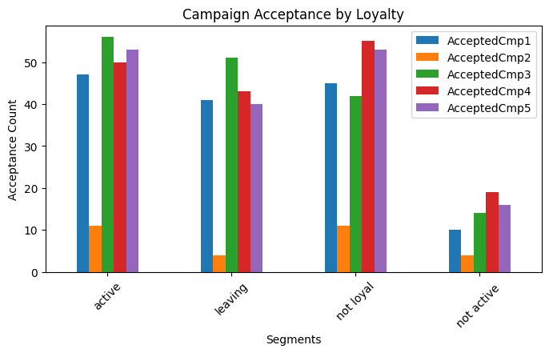

```python
cmp_by_loyalty.plot(kind='bar', figsize=(8,4))
plt.title('Campaign Acceptance by Loyalty')
plt.xlabel('Segments')
plt.ylabel('Acceptance Count')
plt.xticks(rotation=45)
plt.show()
```

## Keskikulutus per henkilö

```python
df2['Total_Consumption'] = df2[['MntWines','MntFruits','MntMeatProducts','MntFishProducts','MntSweetProducts','MntGoldProds']].sum(axis=1)
Number_of_Transactions = df2[['NumDealsPurchases','NumWebPurchases','NumCatalogPurchases', 'NumStorePurchases']].sum(axis=1)
df2['Average_Consumption'] = (df2['Total_Consumption'] / Number_of_Transactions).where(Number_of_Transactions != 0, 0).round(2)
```

Asiakkuuden keskikulutus (ostokertojen per henkilö mukaan) sitoutuneisuuden (recency) ryhmien sisällä:

```python
avg_consumption = (df2.groupby('Loyalty',observed=True)['Average_Consumption'].mean()).round(2)

avg_consumption
```

```
Loyalty
active         32.39
leaving        33.41
not loyal      34.02
not active     33.20
Name: Average_Consumption, dtype: float64
```

Ikäsegmenttien keskikulutus (ostokertojen per henkilö mukaan):

```python
agetoavg = (df2.groupby('age_segment',observed=True)['Average_Consumption'].mean()).round(2)
agetoavg
```

```
age_segment
middle_aged    30.34
pensioner      37.07
young_adult    33.92
Name: Average_Consumption, dtype: float64
```

[figure not shown]

```python
plt.bar(df2['age_segment'],df2['Average_Consumption'], color=('purple'))

plt.title('Average Consumption by Age Segment')
plt.xlabel('Age Segment')
plt.ylabel('Sum')
plt.xticks(rotation=0)
plt.show()
```

## Tuloerot, kulutus ja kampanjat siviisäädyn mukaan

```python
customer_agg = df2.groupby('Marital_Status')['Income'].agg(['sum','mean','median']).round(2)
customer_agg
```

| Marital_Status | sum | mean | median |
| --- | --- | --- | --- |
| Divorced | 12257541.00 | 52834.23 | 52683.00 |
| Married | 44690381.85 | 51724.98 | 51724.98 |
| Single | 24608724.66 | 50949.74 | 49166.00 |
| Together | 30882409.74 | 53245.53 | 52137.00 |
| Widow | 4349079.55 | 56481.55 | 56551.00 |

Vaikka tuloerot ovat näissä mittasuhteissa suht pieniä, näemme kuitenkin pieniä eroja ostoskäyttäytymisessä. Lesket käyttävät keskimäärin eniten rahaa jokaisessa tuoteryhmässä.

```python
products_by_segment = df2.groupby('Marital_Status')[['MntWines','MntFruits','MntMeatProducts','MntFishProducts','MntSweetProducts','MntGoldProds']].agg(['sum','mean']).round(2)
products_by_segment
```

| Marital_Status | MntWines sum | MntWines mean | MntFruits sum | MntFruits mean | MntMeatProducts sum | MntMeatProducts mean | MntFishProducts sum | MntFishProducts mean | MntSweetProducts sum | MntSweetProducts mean | MntGoldProds sum | MntGoldProds mean |
| --- | --- | --- | --- | --- | --- | --- | --- | --- | --- | --- | --- | --- |
| Divorced | 75364 | 324.84 | 6363 | 27.43 | 34848 | 150.21 | 8130 | 35.04 | 6222 | 26.82 | 10739 | 46.29 |
| Married | 258751 | 299.48 | 22235 | 25.73 | 138829 | 160.68 | 30569 | 35.38 | 23070 | 26.70 | 36999 | 42.82 |
| Single | 138953 | 287.69 | 12893 | 26.69 | 87491 | 181.14 | 18367 | 38.03 | 13107 | 27.14 | 21071 | 43.63 |
| Together | 177959 | 306.83 | 14703 | 25.35 | 97500 | 168.10 | 22615 | 38.99 | 15151 | 26.12 | 24937 | 42.99 |
| Widow | 28434 | 369.27 | 2548 | 33.09 | 14575 | 189.29 | 3957 | 51.39 | 3004 | 39.01 | 4371 | 56.77 |

Jos katsotaan kampanjan tehokkuutta siviisäädyn mukaan, näemme selviä eroja. Eronneiden ja sinkkujen ryhmään toimii 3. lampanja, kun taas naimisissa ja avoliitossa olevat suosivat 5. kampanjaa. Lesket suosivat kampanjaa numero 4.

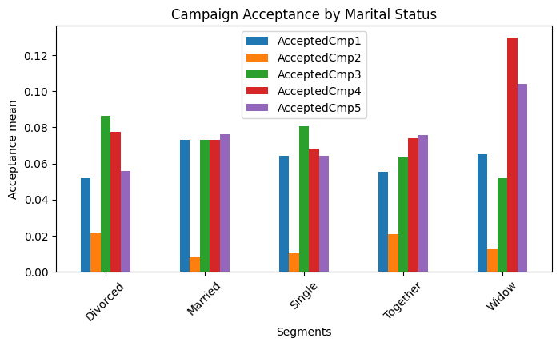

```python
AcceptCMP = df2.groupby('Marital_Status')[['AcceptedCmp1','AcceptedCmp2','AcceptedCmp3','AcceptedCmp4','AcceptedCmp5']].mean()
AcceptCMP.plot(kind='bar', figsize=(8,4))
plt.title('Campaign Acceptance by Marital Status')
plt.xlabel('Segments')
plt.ylabel('Acceptance mean')
plt.xticks(rotation=45)
plt.show()
```